# Sentiment Analysis of Youtube Videos by Their Video Descriptions & Titles

We performed sentiment analysis on our YouTube videos to gauge if there was a difference in the engagement of positive and negative sentiment videos. We then wanted to see if there was a relation in the sentiment of the videos and whether the videos were spreading misinformation or not.

We trained a Logistic Regression model to predict the sentiment of videos. In order to label our videos for training, we researched what percentage of likes on a video deems it successful. On average, receiving likes that total 4-10% of the total views or above is seen as the baseline for a good video. We decided to take the upper limit of 10% and label all videos with a ratio of likes to views higher than 10% as positive. Any video with a ratio that fell below the threshold was labeled negative. We then fed this labeled data into the model with a 80/20 train test split.

We found that the videos with positive sentiment had a slightly higher rate of misinformation (25%) vs negative videos containing misinformation (~17%). These results raise an interesting question of how people react to videos. Are they reacting more positively when given specific types of information or are people being exposed to misinformation content that is more likely to yield a positive reaction?

To summarize, this is our pipeline for sentiment analysis:

1. Look into the distribution of likes, comments, and views (removing outliers)
2. Create a WordCloud for the descriptions (removing stopwords)
3. Separate the positive and negative sentiment videos and create WordClouds for each
- Determine a ratio of likes to views to act as a threshold for positive vs negative sentiment
1. Run a Logistic Regression Model to predict sentiment training on current video data
2. Repeat process on Video Titles

```python
import pandas as pd
import numpy as np
```

```python
import matplotlib.pyplot as plt
import seaborn as sns
color = sns.color_palette()
%matplotlib inline
import plotly.offline as py
py.init_notebook_mode(connected=True)
import plotly.graph_objs as go
import plotly.tools as tls
import plotly.express as px
```

```python
import nltk
from nltk.corpus import stopwords
```

```python
# df = temp
df = pd.read_csv('../../data/youtube_metadata.csv')
df = df.drop(0)
df["like_count"] = pd.to_numeric(df["like_count"])
df["comment_count"] = pd.to_numeric(df["comment_count"])
df["view_count"] = pd.to_numeric(df["view_count"])
df['misinformation'] = ['False', 'True', 'False', 'False', 'False', 'False', 'False', 'False', 'False', 'False',
                        'True', 'False', 'False', 'False', 'True', 'False', 'False', 'False', 'False', 'False',
                        'False', 'False', 'False', 'False', 'False', 'True', 'False', 'True']
# df.iloc[27]
# len(df)
```

```python
df.head()
```

|  | video_title | user | date_posted | like_count | comment_count | view_count | description | topic_details | video_tags | category | misinformation |
| --- | --- | --- | --- | --- | --- | --- | --- | --- | --- | --- | --- |
| 1 | “You’re being detained”: One Woman's Horrific ... | UCln1G-zTVJQlnnnwGrvU8PA | 2021-12-11T02:59:47Z | 1 | 1.0 | 138 | Cathy Blais found out her flight home on Egypt... | ['https://urldefense.proofpoint.com/v2/url?u=https-3A__en.wikipedia.org_wiki_Society&d=DwIGAw&c=-35OiAkTchMrZOngvJPOeA&r=x7X5KKsYn73vQuBQed9uBg&m=J4uA1zwYEDQuqKqM0DOHIMsINycjmPEXB6lvA7oMpgKq0qq-U8slju… | ['omicron', 'covid', 'quarantine', 'africa', '... | News & Politics | False |
| 2 | I Found The Source of the Coronavirus | UCSMrMr8KL6ADMstvYpbYCYA | 2021-12-10T10:41:02Z | 38 | 8.0 | 1155 | I Found The Source of the Coronavirus, I have ... | ['https://urldefense.proofpoint.com/v2/url?u=https-3A__en.wikipedia.org_wiki_Society&d=DwIGAw&c=-35OiAkTchMrZOngvJPOeA&r=x7X5KKsYn73vQuBQed9uBg&m=J4uA1zwYEDQuqKqM0DOHIMsINycjmPEXB6lvA7oMpgKq0qq-U8slju… | ['china', 'coronavirus', 'laowhy86', 'advchina... | News & Politics | True |
| 3 | In person conferences and my opinion | UC2dd23_rKliwoPcCYANq7AA | 2021-07-23T13:31:33Z | 2 | 2.0 | 80 | Fall conference season is coming up, be safe. | ['https://urldefense.proofpoint.com/v2/url?u=https-3A__en.wikipedia.org_wiki_Lifestyle-5F-28soc&d=DwIGAw&c=-35OiAkTchMrZOngvJPOeA&r=x7X5KKsYn73vQuBQed9uBg&m=J4uA1zwYEDQuqKqM0DOHIMsINycjmPEXB6lvA7oMpgK… | NaN | Entertainment | False |
| 4 | ¿Por que solo hay un 35% de vacunados en Parag... | UCMxkaLLyBC8NoPYbPzNvRLg | 2021-12-01T18:31:15Z | 1 | 1.0 | 20 | Carlos Kiese en su programa Deportivo de Radio... | ['https://urldefense.proofpoint.com/v2/url?u=https-3A__en.wikipedia.org_wiki_Society&d=DwIGAw&c=-35OiAkTchMrZOngvJPOeA&r=x7X5KKsYn73vQuBQed9uBg&m=J4uA1zwYEDQuqKqM0DOHIMsINycjmPEXB6lvA7oMpgKq0qq-U8slju… | NaN | Music | False |
| 5 | ÓMICRON: SÍNTOMAS y CLAVES de la nueva variant... | UC1FZF46zaC26_CynNc786_g | 2021-12-02T23:43:17Z | 11017 | 1450.0 | 1177469 | La #variante #ómicron del #coronavirus tras se... | ['https://urldefense.proofpoint.com/v2/url?u=https-3A__en.wikipedia.org_wiki_Society&d=DwIGAw&c=-35OiAkTchMrZOngvJPOeA&r=x7X5KKsYn73vQuBQed9uBg&m=J4uA1zwYEDQuqKqM0DOHIMsINycjmPEXB6lvA7oMpgKq0qq-U8slju… | ['variante omicron', 'que es la variante omicr... | News & Politics | False |

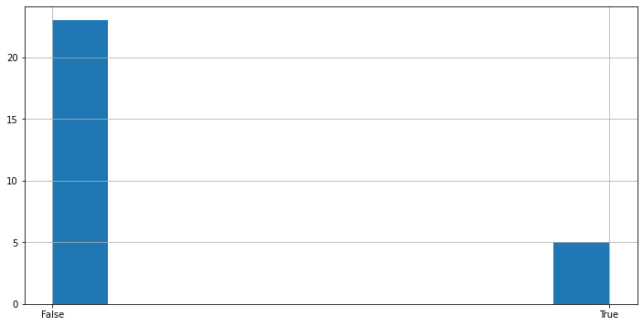

```python
plt.figure(figsize=(12,6))
df.misinformation.hist()
```

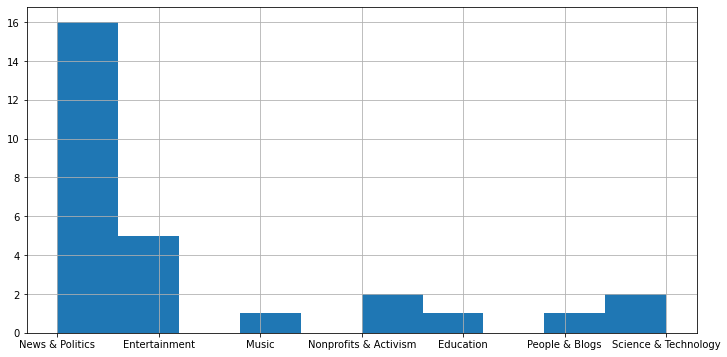

```python
plt.figure(figsize=(12,6))
df.category.hist()
```

```python
# Video Likes
fig = px.histogram(df, x="like_count", nbins=10)
fig.update_traces(marker_color="turquoise",marker_line_color='rgb(8,48,107)',
                  marker_line_width=1.5)
fig.update_layout(title_text='Video Likes')
fig.show()
```

[interactive chart not shown]

### This histogram doesn't show us too much about the data. We can see that a lot of the data is grouped within 100k likes

- We will remove outliers to represent that distribution better

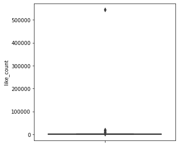

```python
plt.figure(figsize=(5,5))
sns.boxplot(y='like_count',data=df)
```

### There are outlier values at around 500000

- We will remove these to get a better distribution of the like counts below

```python
fig = px.histogram(df[df['like_count'] <200000], x="like_count", nbins=10)
fig.update_traces(marker_color="turquoise",marker_line_color='rgb(8,48,107)',
                  marker_line_width=1.5)
fig.update_layout(title_text='Video Likes')
fig.show()
```

[interactive chart not shown]

```python
# Video Comments
fig = px.histogram(df, x="comment_count", nbins=10)
fig.update_traces(marker_color="turquoise",marker_line_color='rgb(8,48,107)',
                  marker_line_width=1.5)
fig.update_layout(title_text='Video Comments')
fig.show()
```

[interactive chart not shown]

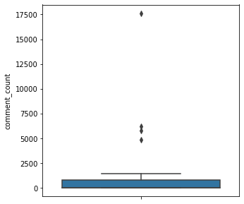

```python
plt.figure(figsize=(5,5))
sns.boxplot(y='comment_count',data=df)
```

```python
fig = px.histogram(df[df['comment_count'] <10000], x="comment_count", nbins=10)
fig.update_traces(marker_color="turquoise",marker_line_color='rgb(8,48,107)',
                  marker_line_width=1.5)
fig.update_layout(title_text='Video Comments')
fig.show()
```

[interactive chart not shown]

```python
# Video Views
fig = px.histogram(df, x="view_count", nbins=10)
fig.update_traces(marker_color="turquoise",marker_line_color='rgb(8,48,107)',
                  marker_line_width=1.5)
fig.update_layout(title_text='Video Views')
fig.show()
```

[interactive chart not shown]

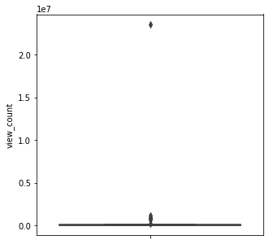

```python
plt.figure(figsize=(5,5))
sns.boxplot(y='view_count',data=df)
```

```python
fig = px.histogram(df[df['view_count'] <1000000], x="view_count", nbins=10)
fig.update_traces(marker_color="turquoise",marker_line_color='rgb(8,48,107)',
                  marker_line_width=1.5)
fig.update_layout(title_text='Video Views')
fig.show()
```

[interactive chart not shown]

### Create a Wordcloud for All Youtube Videos *using descriptions*

```python
# Create stopword list:
from nltk.corpus import stopwords
import seaborn as sns
from wordcloud import WordCloud
# from wordcloud import WordCloud

# stopwords = set(STOPWORDS)
stopwords = set(stopwords.words('english'))
stopwords.update(["br", "href", "https", 'http', 'www', 'com', 'de', 'da',
                  'twitter', 'youtube', 'follow', 'subscribe', 'u', 'que'])
textt = " ".join(review for review in df.description)
wordcloud = WordCloud(stopwords=stopwords).generate(textt)
```

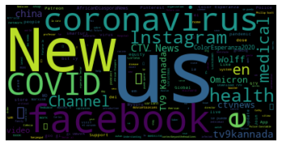

```python
plt.imshow(wordcloud, interpolation='bilinear')
plt.axis("off")
plt.savefig('wordcloud11.png')
plt.show()
```

### We see that Facebook and Instagram are referenced a lot

- Other notable terms are CTV News, tv9kannada, china, wolff, covid, omicron, medical, health
- this may indicate that in the time period, omicron outweighs any other variant in discussion of covid on twitter -> youtube

### Next, we want to see if the top words change between videos with positive and negative sentiment

- We will determine the sentiment labels based on the pratio of likes to views and video recieves
- a video with a ratio greater than 0.1 will be seen as positive

```python
# df = df[df['like_count'] != 3]
# df['sentiment'] = df['Score'].apply(lambda likes : +1 if likes/> 3 else -1)
df['perc_liked'] = df['like_count']/df['view_count']
```

```python
df = df[df['perc_liked'] != .5]
df['sentiment'] = df['perc_liked'].apply(lambda likes : +1 if likes > .1 else -1)
```

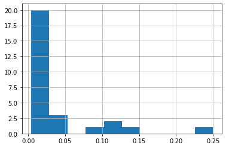

```python
df['perc_liked'].hist()
```

```python
positive = df[df['sentiment'] == 1]
negative = df[df['sentiment'] == -1]
```

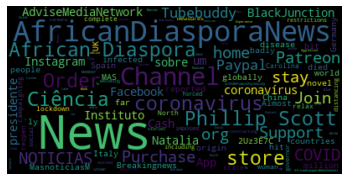

```python
# WORD CLOUD - POSITIVE SENTIMENT
# stopwords = set(stopwords.words('english'))
stopwords.update(["br", "href","good","great", "e", "US", "us", "Us"])
## good and great removed because they were included in negative sentiment
pos = " ".join(review for review in positive.description)
wordcloud2 = WordCloud(stopwords=stopwords).generate(pos)
plt.imshow(wordcloud2, interpolation='bilinear')
plt.axis("off")
plt.show()
```

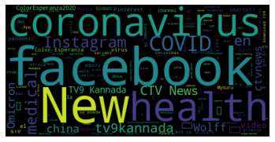

```python
# WORD CLOUD - NEGATIVE SENTIMENT
neg = " ".join(review for review in negative.description)
wordcloud3 = WordCloud(stopwords=stopwords).generate(neg)
plt.imshow(wordcloud3, interpolation='bilinear')
plt.axis("off")
plt.savefig('wordcloud33.png')
plt.show()
```

```python
df['sentimentt'] = df['sentiment'].replace({-1 : 'negative'})
df['sentimentt'] = df['sentimentt'].replace({1 : 'positive'})
fig = px.histogram(df, x="sentimentt")
fig.update_traces(marker_color="indianred",marker_line_color='rgb(8,48,107)',
                  marker_line_width=1.5)
fig.update_layout(title_text='Video Sentiment')
fig.show()
```

[interactive chart not shown]

```python
def remove_punctuation(text):
    final = "".join(u for u in text if u not in ("?", ".", ";", ":",  "!",'"'))
    return final
df['Text'] = df['category'].apply(remove_punctuation)
df = df.dropna(subset=['description'])
df['description'] = df['description'].apply(remove_punctuation)
```

```python
dfNew = df[['description','sentiment']]
dfNew.head()
```

|  | description | sentiment |
| --- | --- | --- |
| 1 | Cathy Blais found out her flight home on Egypt... | -1 |
| 2 | I Found The Source of the Coronavirus, I have ... | -1 |
| 3 | Fall conference season is coming up, be safe | -1 |
| 4 | Carlos Kiese en su programa Deportivo de Radio... | -1 |
| 5 | La #variante #ómicron del #coronavirus tras se... | -1 |

```python
# random split train and test data
index = df.index
df['random_number'] = np.random.randn(len(index))
train = df[df['random_number'] <= 0.8]
test = df[df['random_number'] > 0.8]
```

```python
# count vectorizer:
from sklearn.feature_extraction.text import CountVectorizer
vectorizer = CountVectorizer(token_pattern=r'\b\w+\b')
train_matrix = vectorizer.fit_transform(train['description'])
test_matrix = vectorizer.transform(test['description'])
```

```python
# Logistic Regression
from sklearn.linear_model import LogisticRegression
lr = LogisticRegression()
```

```python
X_train = train_matrix
X_test = test_matrix
y_train = train['sentiment']
y_test = test['sentiment']
```

```python
lr.fit(X_train,y_train)
```

```
LogisticRegression()
```

```python
predictions = lr.predict(X_test)
```

```python
# find accuracy, precision, recall:
from sklearn.metrics import confusion_matrix,classification_report
new = np.asarray(y_test)
confusion_matrix(predictions,y_test)
```

```
array([[5, 1],
       [0, 0]])
```

```python
print(classification_report(predictions,y_test))
```

```
              precision    recall  f1-score   support

          -1       1.00      0.83      0.91         6
           1       0.00      0.00      0.00         0

    accuracy                           0.83         6
   macro avg       0.50      0.42      0.45         6
weighted avg       1.00      0.83      0.91         6
```

## Let's Repeat the Above Analysis on Video Titles Alone

```python
# stopwords = set(stopwords.words('english'))
stopwords.update(["br", "href", "https", 'http', 'www', 'com', 'de', 'da',
                  'twitter', 'youtube', 'follow', 'subscribe', 'u', 'que'])
textt = " ".join(review for review in df.video_title)
wordcloud = WordCloud(stopwords=stopwords).generate(textt)
```

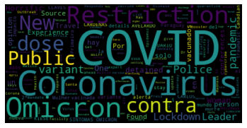

```python
plt.imshow(wordcloud, interpolation='bilinear')
plt.axis("off")
plt.savefig('wordcloud11.png')
plt.show()
```

For the titles, we see that Publiic Restriction, COVID, Omicron, detained, dose, variant are all heavily found

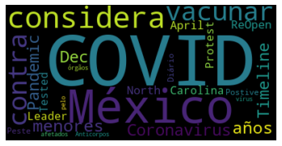

```python
# WORD CLOUD - POSITIVE SENTIMENT VIDEO TITLES
# stopwords = set(stopwords.words('english'))
stopwords.update(["br", "href","good","great"])
## good and great removed because they were included in negative sentiment
pos = " ".join(review for review in positive.video_title)
wordcloud2 = WordCloud(stopwords=stopwords).generate(pos)
plt.imshow(wordcloud2, interpolation='bilinear')
plt.axis("off")
plt.show()
```

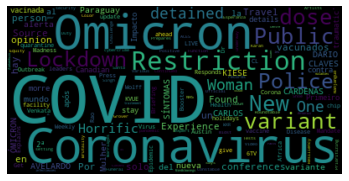

```python
# WORD CLOUD - NEGATIVE SENTIMENT VIDEO TITLES
neg = " ".join(review for review in negative.video_title)
wordcloud3 = WordCloud(stopwords=stopwords).generate(neg)
plt.imshow(wordcloud3, interpolation='bilinear')
plt.axis("off")
plt.savefig('wordcloud33.png')
plt.show()
```

```python
def remove_punctuation(text):
    final = "".join(u for u in text if u not in ("?", ".", ";", ":",  "!",'"'))
    return final
df['Text'] = df['description'].apply(remove_punctuation)
df = df.dropna(subset=['video_title'])
df['video_title'] = df['video_title'].apply(remove_punctuation)
```

```python
dfNew = df[['description','sentiment']]
dfNew.head()
```

|  | description | sentiment |
| --- | --- | --- |
| 1 | Cathy Blais found out her flight home on Egypt... | -1 |
| 2 | I Found The Source of the Coronavirus, I have ... | -1 |
| 3 | Fall conference season is coming up, be safe | -1 |
| 4 | Carlos Kiese en su programa Deportivo de Radio... | -1 |
| 5 | La #variante #ómicron del #coronavirus tras se... | -1 |

```python
# random split train and test data
index = df.index
df['random_number'] = np.random.randn(len(index))
train = df[df['random_number'] <= 0.8]
test = df[df['random_number'] > 0.8]
```

```python
# count vectorizer:
from sklearn.feature_extraction.text import CountVectorizer
vectorizer = CountVectorizer(token_pattern=r'\b\w+\b')
train_matrix = vectorizer.fit_transform(train['description'])
test_matrix = vectorizer.transform(test['description'])
```

```python
# Logistic Regression
from sklearn.linear_model import LogisticRegression
lr = LogisticRegression()
```

```python
X_train = train_matrix
X_test = test_matrix
y_train = train['sentiment']
y_test = test['sentiment']
```

```python
lr.fit(X_train,y_train)
```

```
LogisticRegression()
```

```python
predictions = lr.predict(X_test)
```

```python
# find accuracy, precision, recall:
from sklearn.metrics import confusion_matrix,classification_report
new = np.asarray(y_test)
confusion_matrix(predictions,y_test)
```

```
array([[6, 2],
       [0, 0]])
```

```python
print(classification_report(predictions,y_test))
```

```
              precision    recall  f1-score   support

          -1       1.00      0.75      0.86         8
           1       0.00      0.00      0.00         0

    accuracy                           0.75         8
   macro avg       0.50      0.38      0.43         8
weighted avg       1.00      0.75      0.86         8
```

### We also wanted to compare the amount of positive and negative sentiment videos that were related to misinformation

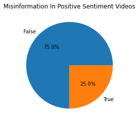

```python
# plt.pie(df[df['sentiment'] == 1])
plt.pie(df[df['sentiment'] == 1]['misinformation'].value_counts(), labels = ['False', 'True'], autopct='%1.1f%%')
plt.title('Misinformation In Positive Sentiment Videos')
```

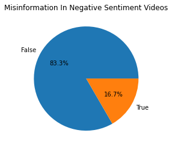

```python
plt.pie(df[df['sentiment'] == -1]['misinformation'].value_counts(), labels = ['False', 'True'], autopct='%1.1f%%')
plt.title('Misinformation In Negative Sentiment Videos')
```